# Fitting Data

```python
import matplotlib.pyplot as plt
import numpy as np

from astropy.table import QTable
from astropy import units as u
from astropy import constants as const
from scipy.optimize import curve_fit
```

# Power on the Moon

[figure not shown]

- The Apollo lunar mission deployed a series of experiments on the Moon.
- The experiment package was called the Apollo Lunar Surface Experiments Package [(ALSEP)](https://en.wikipedia.org/wiki/Apollo_Lunar_Surface_Experiments_Package)
- The ALSEP was powered by a radioisotope thermoelectric generator [(RTG)](https://en.wikipedia.org/wiki/Radioisotope_thermoelectric_generator)
- An RTG is basically a fist-sized slug of Pu-238 wrapped in a material that generates electric power when heated.
- Since the RTG is powered by a radioisotope, the output power decreases over time as the radioisotope decays.

## Read in the datafile

The data file `https://uwashington-astro300.github.io/A300_Data/Apollo_RTG.csv` contains the power output of the Apollo 12 RTG as a function of time.

The data colunms are

- [Day] - Days on the Moon
- [Power] - RTG power output in Watts

Read in the datafile as a astropy `QTable`

```python
my_data1 = QTable.read('https://uwashington-astro300.github.io/A300_Data/Apollo_RTG.csv',
                       format='ascii.csv')
```

Add units to the columns

```python
my_data1['Day'].unit = u.d
my_data1['Power'].unit = u.watt
```

## Plot the Data

- Day vs. Power
- Fit the function with a (degree = 3) polynomial
- Plot the fit with the data
- Output size w:11in, h:8.5in
- Make the plot look nice (including clear labels)

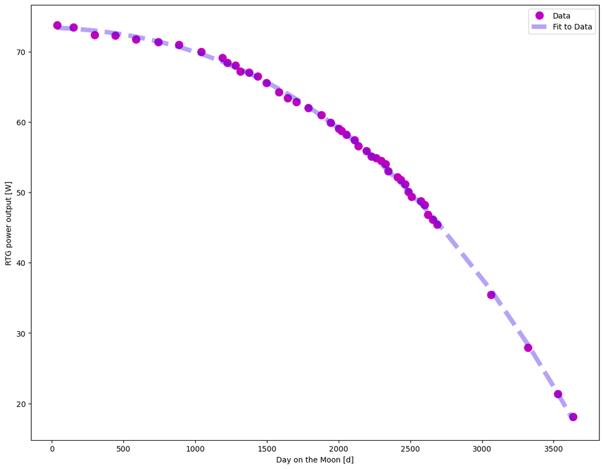

```python
my_x = my_data1['Day']
my_y = my_data1['Power']

my_fit1 = np.polyfit(my_x.value, my_y.value, 3)
fitted_polynomial = np.poly1d(my_fit1)
my_data1['Fit'] = fitted_polynomial(my_x.value)* my_y.unit

fig, ax = plt.subplots(
    figsize = (11, 8.5),
    constrained_layout = True
)

ax.set_xlabel(f"Day on the Moon [{my_x.unit}]")
ax.set_ylabel(f"RTG power output [{my_y.unit}]")

ax.plot(my_x, my_y,
        color = "m",
        marker = "o",
        linestyle = "None",
        markersize = 10,
        label="Data");

ax.plot(my_x, my_data1['Fit'],
        marker = "None",
        linewidth = 6,
        color = (0.3, 0.1, 0.9, 0.4),
        linestyle = '--',
        label = "Fit to Data")

ax.legend(loc=0);
```

## Power over time

- All of your answer should be formatted as sentences
- For example: `The power on day 0 is VALUE UNIT`
- Pay attention to the requested output units
- Do not pick the complex roots!

### 1 - What was the power output on Day 0?

```python
fitted_polynomial(0)
```

```
np.float64(73.40136180091336)
```

```python
f"The power on day 0 is {fitted_polynomial(0):.1f} {my_y.unit}"
```

```
'The power on day 0 is 73.4 W'
```

### 2 - How many YEARS after landing could you still power a 60 W lightbulb?

```python
my_solution2 = (fitted_polynomial - 60).roots
real_solution2 = my_solution2[np.isreal(my_solution2)].real

my_year2 = (real_solution2[0] * my_x.unit).to(u.yr)
```

```python
f"Up to {my_year2.value:.1f}{my_year2.unit} after landing"
```

```
'Up to 5.3yr after landing'
```

### 3 - How many YEARS after landing could you still power a 5 W USB device?

```python
my_solution3 = (fitted_polynomial - 5).roots
real_solution3 = my_solution3[np.isreal(my_solution3)].real

my_year3 = (real_solution3[0] * my_x.unit).to(u.yr)
```

```python
f"Up to {my_year3.value:.1f}{my_year3.unit} after landing"
```

```
'Up to 10.8yr after landing'
```

### 4 - How many YEARS after landing until the power output is 0 W?

```python
my_solution4 = fitted_polynomial.roots
real_solution4 = my_solution4[np.isreal(my_solution4)].real

my_year4 = (real_solution4[0] * my_x.unit).to(u.yr)
```

```python
f"Up to {my_year4.value:.1f}{my_year4.unit} after landing"
```

```
'Up to 11.2yr after landing'
```

# Fitting data to a function

- The datafile `https://uwashington-astro300.github.io/A300_Data/linedata.csv` contains two columns of data [no units]

#### Read in the Data as an astropy `Qtable`

```python
my_data2 = QTable.read('https://uwashington-astro300.github.io/A300_Data/linedata.csv',
                       format='ascii.csv')
```

#### Plot the Data

- Output size w:11in, h:8.5in
- Make the plot look nice (including clear labels and a legend)

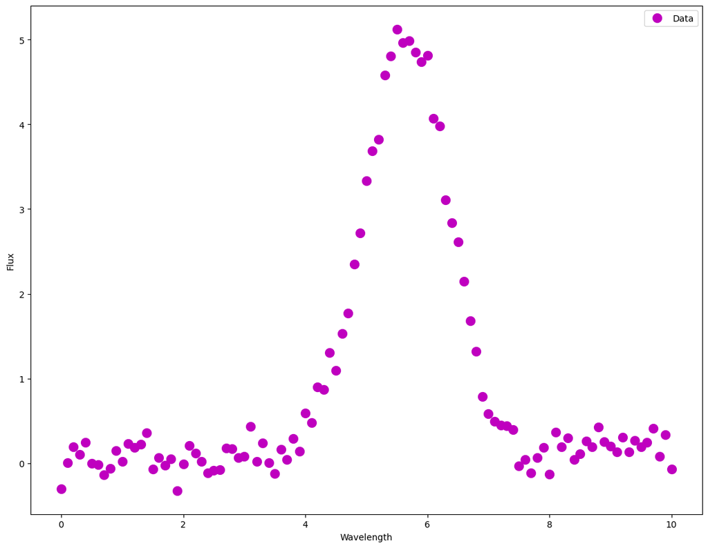

```python
my_x2 = my_data2['wavelength']
my_y2 = my_data2['flux']

fig, ax = plt.subplots(
    figsize = (11, 8.5),
    constrained_layout = True
)

ax.set_xlabel(f"Wavelength")
ax.set_ylabel(f"Flux")

ax.plot(my_x2, my_y2,
        color = "m",
        marker = "o",
        linestyle = "None",
        markersize = 10,
        label = "Data");

ax.legend(loc=0);
```

#### Fit a gaussian of the form:

- A = amplitude of the gaussian
- C = x-value of the central peak of the gaussian
- W = width of the gaussian
- Find the values `(A,C,W)` that best fit the data

```python
def gauss(x, A, C, W):
    return A * np.exp(-(x - C)**2 / (W**2))
```

```python
my_guess_A=my_y2.max()
my_guess_C=my_x2[np.argmax(my_y2)]
my_guess_W=(my_x2.max()-my_x2.min())/5

init_guess=[my_guess_A, my_guess_C, my_guess_W]

fitpars, error = curve_fit(gauss, my_x2, my_y2, p0=init_guess)

A, C, W = fitpars

print(fitpars)
f"The values of A, C, and W are {A}, {C}, and {W} after landing"
```

```
[5.0780061  5.65866107 0.98663261]
```

```
'The values of A, C, and W are 5.078006101918849, 5.65866107446586, and 0.9866326059529993 after landing'
```

#### Plot the Data and the Fit on the same plot

- Output size w:11in, h:8.5in
- Make the plot look nice (including clear labels and a legend)

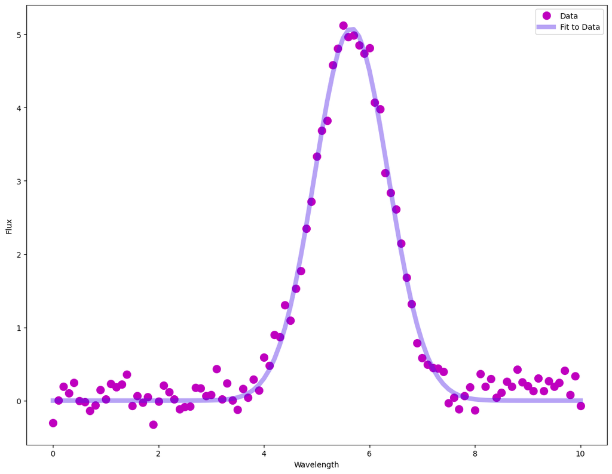

```python
my_x2 = my_data2['wavelength']
my_y2 = my_data2['flux']

fig, ax = plt.subplots(
    figsize = (11, 8.5),
    constrained_layout = True
)

ax.set_xlabel(f"Wavelength")
ax.set_ylabel(f"Flux")

ax.plot(my_x2, my_y2,
        color = "m",
        marker = "o",
        linestyle = "None",
        markersize = 10,
        label = "Data");

ax.plot(my_x2, gauss(my_x2.value, *fitpars),
        color = (0.3, 0.1, 0.9, 0.4),
        marker = "None",
        linestyle = "-",
        linewidth = 6,
        label = "Fit to Data")

ax.legend(loc=0);
```

### Due Wed Feb 11 - 1 pm

- `File -> Download as -> HTML (.html)`
- `upload your .html file to the class Canvas page`